# Clustering

## Dataset

Three simulated datasets *noisy.circles*, *noisy.moons*, *blobs* of 1500 observations x 2 features containing 2, 2, and 3 clusters respectively.

```r
head(noisy.circles)
```

```
##           x1          x2 y
## 1 -0.4412984 -0.26011650 1
## 2  0.6052318 -0.65733542 0
## 3  1.0344003  0.05708226 0
## 4  0.4442293  0.03467232 1
## 5 -0.2264144  0.46547732 1
## 6  0.5648620 -0.81670969 0
```

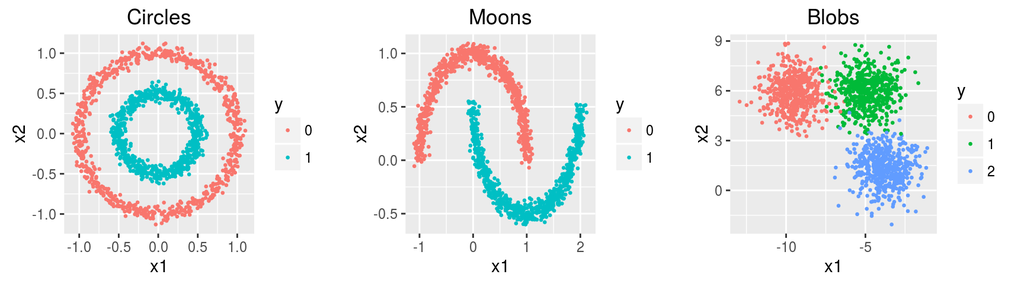

## k-means

The k-means optimization problem is to find the set C of cluster centers $\mathbf c \in \mathbb R^m$, with $|C| = k$, to minimize over a set of examples $\mathbf x \in \mathbb R^m$ the following objective function:
$$\min \sum_{\mathbf x \in X} ||f(C, \mathbf x) - \mathbf x||^2$$
Here, $f(C, \mathbf x)$ returns the nearest cluster center $\mathbf c \in C$ to $\mathbf x$ using Euclidean distance.

```r
noisy.circles.km <- kmeans(noisy.circles[,1:2], centers = 2, iter.max = 100,
                           nstart = 10)
noisy.moons.km <- kmeans(noisy.moons[,1:2], centers = 2, iter.max = 100,
                         nstart = 10)
blobs.km <- kmeans(blobs[,1:2], centers = 3, iter.max = 100,
                   nstart = 10)

head(noisy.circles.km$cluster, 10)
```

```
##  [1] 1 2 2 2 1 2 2 1 2 2
```

```r
noisy.circles.km$centers
```

```
##           x1         x2
## 1 -0.4007305  0.2630556
## 2  0.4004353 -0.2627844
```

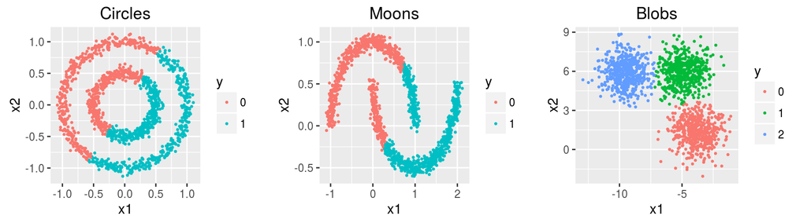

## k-medoids

Similar to the k-means algorithm, but in the k-medoids algorithm, the center of the subset is a member of the subset, called a medoid (i.e., cluster centers $\mathbf c \in X$). In the k-means algorithm, the center of the subset is the centroid.

```r
noisy.circles.pam <- pam(noisy.circles[,1:2], k = 2, cluster.only = T)
noisy.moons.pam <- pam(noisy.moons[,1:2], k = 2, cluster.only = T)
blobs.pam <- pam(blobs[,1:2], k = 3, cluster.only = T)

head(noisy.circles.pam, 10)
```

```
##  [1] 1 1 2 2 2 1 1 2 1 2
```

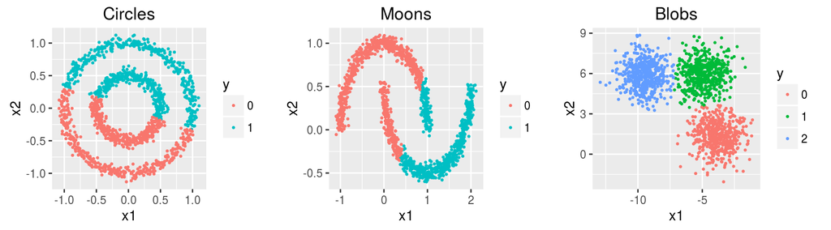

## Heirarchial Clustering

Hierarchical clustering groups data into a multilevel cluster tree or dendrogram. *hclust()* constructs the agglomerative hierarchical cluster tree.

Model specifications:

- Linkage criteria: Complete Linkage, $\max\{\,d(x,y):x\in {\mathcal {A}},\,y\in {\mathcal {B}}\,\}$
- Similarity measure: Euclidean distance, $d(x, y) = \|x - y\|_2$
- Desired number of groups = 2, 2, 3 for *circles*, *moons*, *blobs* respectively. (This determines where to cut the tree).

```r
# euclidean distance and complete-linkage
noisy.circles.hc <- hclust(dist(noisy.circles[,1:2]))
noisy.circles.hc.clus <- cutree(noisy.circles.hc, k = 2)

noisy.moons.hc <- hclust(dist(noisy.moons[,1:2]))
noisy.moons.hc.clus <- cutree(noisy.moons.hc, k = 2)

blobs.hc <- hclust(dist(blobs[,1:2]))
blobs.hc.clus <- cutree(blobs.hc, k = 3)

head(noisy.circles.hc.clus, 10)
```

```
##  [1] 1 1 2 2 2 1 1 2 1 2
```

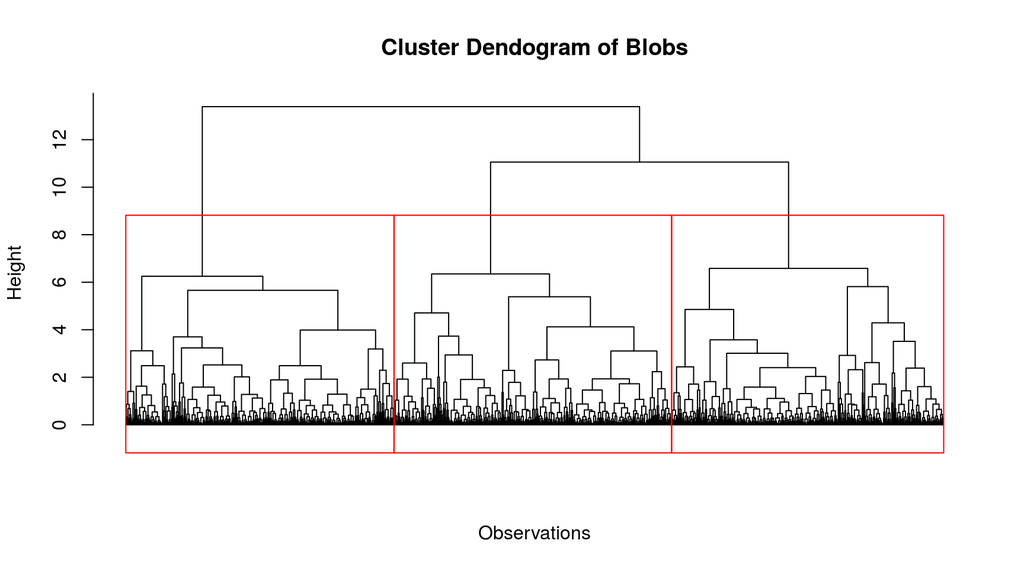

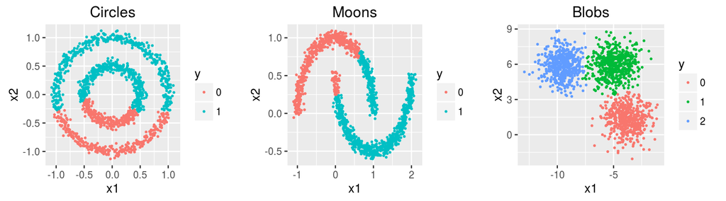